# 02 Exercises

```r
nrow(Boston[Boston$crim > 20, ])
```

```
## [1] 18
```

```
Most of the suburbs have low crime rates.  However, there is a long tail with 18 suburbs with a crime rate > 20
reaching to above 80
```

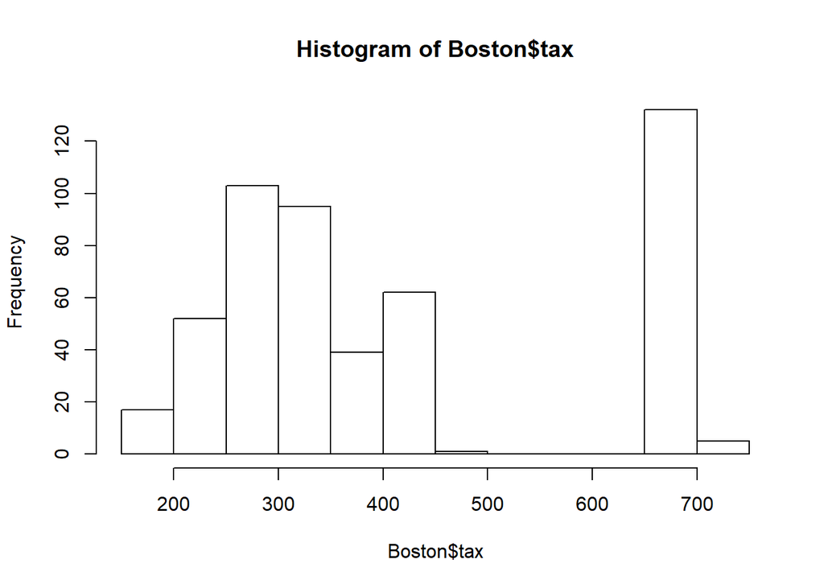

```r
hist(Boston$tax)
```

```r
summary(Boston$tax)
```

```
##    Min. 1st Qu.  Median    Mean 3rd Qu.    Max.
##   187.0   279.0   330.0   408.2   666.0   711.0
```

[output not shown]

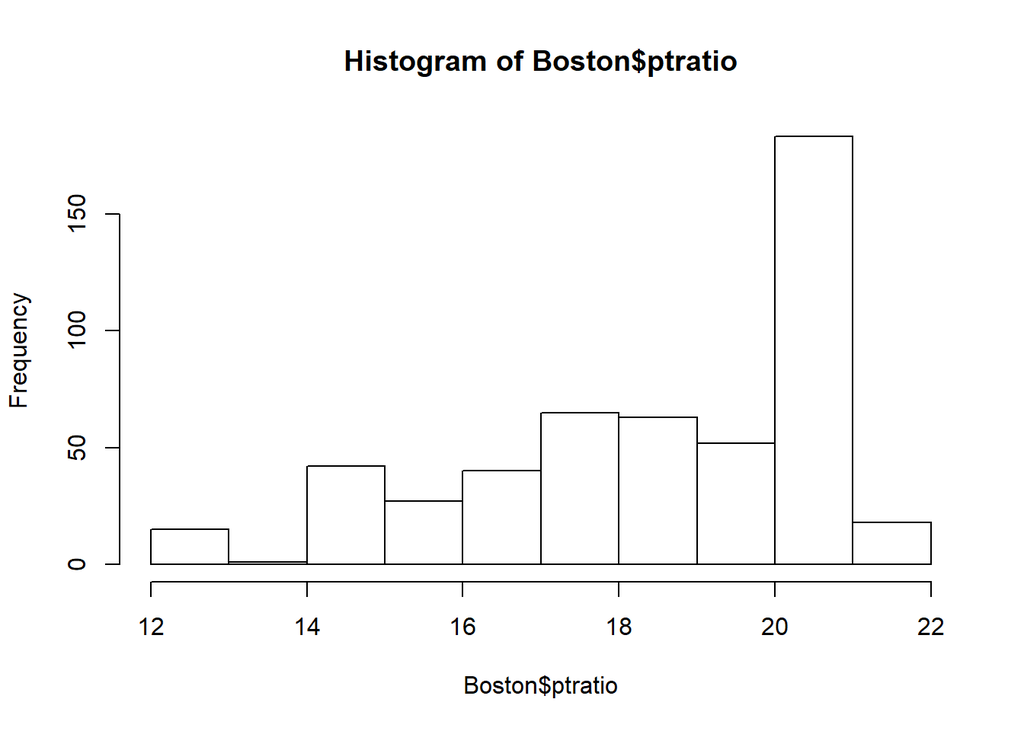

```r
hist(Boston$ptratio)
```

```r
summary(Boston$ptratio)
```

```
##    Min. 1st Qu.  Median    Mean 3rd Qu.    Max.
##   12.60   17.40   19.05   18.46   20.20   22.00
```

```
Pupil-teacher ratios are spread across with a negative skew.
```

How many of the suburbs in this data set bound the Charles river?

```r
table(Boston$chas)
```

```
##
##   0   1
## 471  35
```

What is the median pupil-teacher ratio among the towns in this data set?

```r
median(Boston$ptratio)
```

```
## [1] 19.05
```

Which suburb of Boston has lowest median value of owneroccupied homes? What are the values of the other predictors for that suburb, and how do those values compare to the overall ranges for those predictors? Comment on your findings.

```r
Boston[Boston$medv == min(Boston$medv), ]
```

```
##        crim zn indus chas   nox    rm age    dis rad tax ptratio  black
## 399 38.3518  0  18.1    0 0.693 5.453 100 1.4896  24 666    20.2 396.90
## 406 67.9208  0  18.1    0 0.693 5.683 100 1.4254  24 666    20.2 384.97
##     lstat medv
## 399 30.59    5
## 406 22.98    5
```

```r
sapply(Boston, quantile)
```

```
##           crim    zn indus chas   nox     rm     age       dis rad tax
## 0%    0.006320   0.0  0.46    0 0.385 3.5610   2.900  1.129600   1 187
## 25%   0.082045   0.0  5.19    0 0.449 5.8855  45.025  2.100175   4 279
## 50%   0.256510   0.0  9.69    0 0.538 6.2085  77.500  3.207450   5 330
## 75%   3.677083  12.5 18.10    0 0.624 6.6235  94.075  5.188425  24 666
## 100% 88.976200 100.0 27.74    1 0.871 8.7800 100.000 12.126500  24 711
##      ptratio    black  lstat   medv
## 0%     12.60   0.3200  1.730  5.000
## 25%    17.40 375.3775  6.950 17.025
## 50%    19.05 391.4400 11.360 21.200
## 75%    20.20 396.2250 16.955 25.000
## 100%   22.00 396.9000 37.970 50.000
```

```
Compared to the overall ranges,
- age & rad of the lowest median value suburbs are at the max.
- crim, indus, nox, tax, ptratio, lstat are either at or above the 75th percentile.
- low for zn, rm, dis.
```

In this data set, how many of the suburbs average more than seven rooms per dwelling? More than eight rooms per dwelling? Comment on the suburbs that average more than eight rooms per dwelling.

```r
nrow(Boston[Boston$rm > 7, ])
```

```
## [1] 64
```

```r
nrow(Boston[Boston$rm > 8, ])
```

```
## [1] 13
```

```r
rbind(sapply(Boston[Boston$rm > 8,], mean), sapply(Boston, median))
```

```
##           crim       zn    indus      chas       nox       rm      age
## [1,] 0.7187954 13.61538 7.078462 0.1538462 0.5392385 8.348538 71.53846
## [2,] 0.2565100  0.00000 9.690000 0.0000000 0.5380000 6.208500 77.50000
##           dis      rad      tax  ptratio    black lstat medv
## [1,] 3.430192 7.461538 325.0769 16.36154 385.2108  4.31 44.2
## [2,] 3.207450 5.000000 330.0000 19.05000 391.4400 11.36 21.2
```

```
- Crime rates are higher (almost 3x)
- higher proportion of 25k sq foot lots
- much lower lstat value
- higher medv value
```